# VTE 與 *Cancer-Associated VTE* 治療策略

# Kaplan-Meier：時間軸上看出血與復發

出血曲線從第一週起即開始分離；recurrent VTE 兩條曲線完全重疊

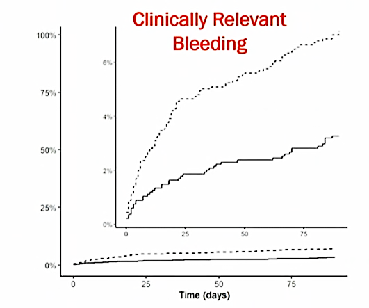

臨床顯著出血 — Apixaban (實線) vs Rivaroxaban (虛線)  
**事件率 ~3% vs ~7%**

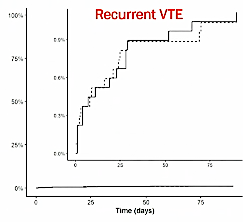

復發 VTE — 兩條曲線重疊  
**~1% vs ~1%，HR 1.08**

Reproduced from Castellucci L. *ISTH 2025 LB 01 oral presentation.*

Case A · Treatment Plan

# 回到 Anne — 處方建議

| 治療計畫 | 細節 |
| --- | --- |
| **啟動 apixaban** | Loading 10 mg BID × 7 days |
| 維持劑量 | 5 mg BID × 6 個月，6 個月時重新評估是否延長治療 |
| 追蹤 | 抗凝門診定期追蹤；衛教**出血徵象**與**復發症狀** |

**COBRRA take-home：**對沒有癌症的急性 VTE 病人，apixaban 在頭對頭比較中**顯著降低 56% 臨床顯著出血**，且**不犧牲復發 VTE 預防效果**。這支持 apixaban 作為非癌症 acute VTE 的優先選擇。

Eliquis® (apixaban) 5 mg film-coated tablets. Summary of Product Characteristics. Apr 2025.

PART · B

# 急性 Cancer-Associated VTE

Case B · Priya, 60 yo · Gastric cancer

癌症併發 VTE

# Priya — 60 歲女性，胃癌轉移合併右下肢近端 DVT

### 病史 & 治療

- **Gastric cancer** — 化療 + partial gastrectomy；緩解 ~18 個月後最近 CT 發現轉移
- 31 年前 postpartum DVT (UFH 1 週 + warfarin 3 個月)
- HTN — Lisinopril 10 mg QD

### 本次入院

- 右下肢腫脹、輕度壓痛，無胸部症狀
- Doppler: **近端 DVT (right popliteal)**
- D-dimer 750 ng/mL

| 理學與檢驗 |  |
| --- | --- |
| BP / HR | 130/80 · 80 bpm |
| SpO₂ / 體重 | 96% RA · 66 kg |
| BMI | 20 kg/m² |
| Hb / Plt | 125 g/L · 245 × 10⁹/L |
| **CrCl** | **65 mL/min** |
| CT abdo | 無局部復發 (僅轉移) |

**臨床問題：**癌症族群的急性 VTE，能否用 DOAC？是 LMWH 還是 apixaban 較好？

虛構臨床情境，僅供教學使用 · CrCl, creatinine clearance.

Cancer-Associated VTE · Epidemiology

# 癌症與 VTE — 不只是巧合，是放大鏡

*9*×癌症病人 VTE 風險相對  
一般人提高至 9 倍

20–30%所有「首次 VTE」  
發生在癌症病人

2<sup>nd</sup>血栓 = 癌症病人  
第二大死因（次於癌症進展）

Ca-VTE 不只是治療「血栓」這件事 — 還會延長住院、增加再入院、影響化療、降低生活品質、提高死亡率。  
**抗凝決策需在「復發風險」與「出血風險」之間動態平衡。**

**Refs:** Mulder FI, et al. *Blood*. 2021;137:1959–69 · Timp JF, et al. *Blood*. 2013;122:1712–23 · Khorana AA, et al. *Nat Rev Dis Primers*. 2022;8:11.

DOAC RCTs in Ca-VTE

# Ca-VTE 的六大 DOAC 隨機試驗速覽

不同設計、不同對照藥、不同 endpoint — 不可直接相互比較

| 試驗 | 實驗藥 | 設計 | 療程 | N | 主要 endpoint |
| --- | --- | --- | --- | --- | --- |
| Hokusai-VTE Cancer 2018 | Edoxaban | Non-inferiority PROBE | 6–12 mo | 1,046 | Recurrent VTE 或 major bleed |
| SELECT-D 2018 | Rivaroxaban | Pilot open-label | 6 mo | 406 | Recurrent VTE |
| ADAM VTE 2019 | Apixaban | Superiority open-label | 6 mo | 287 | Major bleeding |
| **CARAVAGGIO 2020** | Apixaban | Non-inferiority PROBE | 6 mo | 1,155 | Efficacy: recurrent VTE Safety: major bleed |
| CASTA-DIVA 2022 | Rivaroxaban | Non-inferiority RCT | 3 mo | 158 | Recurrent VTE |
| CANVAS 2023 | Any DOAC vs LMWH | Comparative effectiveness | 6 mo | 638 | Recurrent VTE |

**Refs:** Raskob 2018 · Young 2018 · McBane 2020 · Agnelli 2020 · Planquette 2022 · Schrag 2023.

Meta-analysis · Frere 2022

# DOAC vs LMWH 的整合分析 — 復發 VTE

DOAC 在 Ca-VTE 顯著降低復發；6 篇 RCT，n = 3,690

試驗

DOAC  
n/N

LMWH  
n/N

RR (95% CI) Favours DOAC ← | → Favours LMWH

HOKUSAI-VTE CANCER

34/522

46/524

0.74 (0.48–1.14)

SELECT-D

8/203

18/203

0.44 (0.20–1.00)

ADAM VTE

1/145

9/142

0.11 (0.01–0.85)

CARAVAGGIO

32/576

46/579

0.70 (0.45–1.08)

CASTA-DIVA

4/74

6/84

0.76 (0.22–2.58)

CANVAS

20/330

27/308

0.69 (0.40–1.21)

**Total (random)**

99/1,850

152/1,840

**0.67 (0.52–0.85)**

I² = 0% · Z = 3.22, P = 0.001 — **DOAC 顯著降低 33% 復發 VTE 風險**

Frere C, et al. *J Hematol Oncol.* 2022;15:69.

CARAVAGGIO · NEJM 2020

Investigator-initiated PROBE Trial

# CARAVAGGIO：Apixaban 對抗 Dalteparin 在 Ca-VTE

### 研究目的

Apixaban 在預防癌症病人 VTE 復發上，是否**非劣於 dalteparin**？  
(達到 non-inferiority 後，secondary 進行 superiority 檢定)

### 納入族群

- 近端 DVT (popliteal 及以上) 或 segmental PE，<72 h 內
- 所有確診癌症 (排除：basal/squamous skin cancer、primary brain tumor、CNS metastases、acute leukemia)

### 兩組治療 × 6 個月

A 組 (n = 576) Apixaban 10 mg BID × 7 d → 5 mg BID

B 組 (n = 579) Dalteparin (LMWH) 200 IU/kg SC QD × 30 d → 150 IU/kg QD

**Endpoints：** Primary efficacy = 復發 VTE / Primary safety = major bleeding

Agnelli G, et al. *N Engl J Med.* 2020;382:1599–607 · Agnelli G, et al. *Thromb Haemost.* 2018;118:1668–78.

CARAVAGGIO · Clinical Outcomes

# 主要結果：Apixaban 非劣於 Dalteparin

Recurrent VTE 5.6% vs 7.9% (HR 0.63, P<0.001 for NI)；Major bleeding 兩組相當

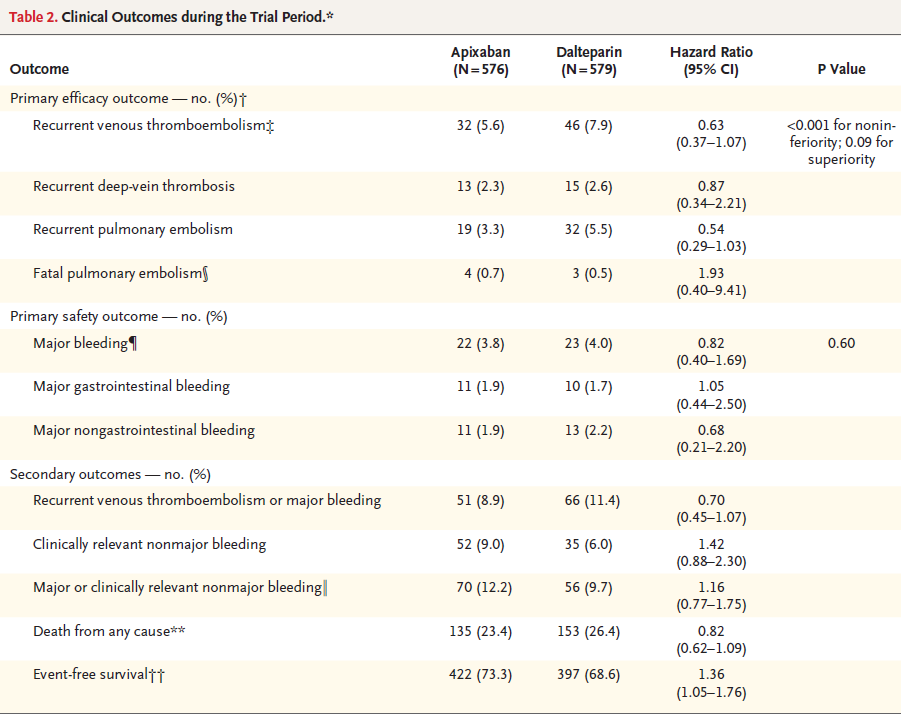

Reproduced from Agnelli G, et al. *N Engl J Med.* 2020;382:1599–607, Table 2.

Apixaban 同時提供**非劣效（甚至數值上更好）**的復發保護，**不增加 major bleed**；CRNM bleed 略多但未達顯著。

CARAVAGGIO · GI cancer subgroup

# GI 癌症亞組分析 — Apixaban 的安全性

與 Hokusai/SELECT-D 的差異：apixaban 在 luminal GI cancer **未見明顯出血訊號**

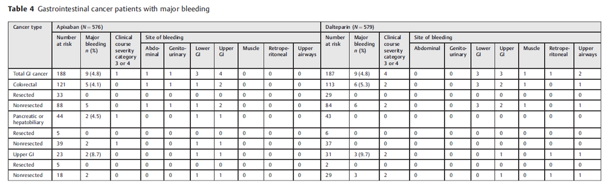

GI 癌症的 Major bleeding  
Reproduced from Ageno W, et al. *Thromb Haemost.* 2021;121:616–24, Table 4.

### 兩組數字相當

|  | Apixaban | Dalteparin |
| --- | --- | --- |
| GI 癌症 Major bleed | 9 / 188 (4.8%) | 9 / 187 (4.8%) |
| Lower GI | 3 | 3 |
| Upper GI | 4 | 3 |
| 臨床顯著 GI bleed (含 CRNM) | 15 / 188 (8.0%) | 14 / 187 (7.5%) |

注意：CARAVAGGIO 的**有效樣本數不足**以對「出血」做最終結論；但 trend 與 edoxaban / rivaroxaban 過往結果不同，**支持 apixaban 在 luminal GI cancer 的可用性**（多數指引現亦建議 apixaban 為 luminal GI cancer 較佳選擇）。

Ageno W, et al. *Thromb Haemost.* 2021;121:616–24.

Guideline Evolution

# 指引演進 — 從 LMWH-only 到 DOAC-first

CARAVAGGIO 是改變指引語言的關鍵 trial

| 指引 (年) | 第一線 | 備註 |
| --- | --- | --- |
| 2018 ISTH | LMWH | Edoxaban / rivaroxaban 替代（若無 GI cancer） |
| 2019 ESC PE | LMWH | VKA 為替代 |
| 2021 ASH | DOAC (apixaban / edoxaban / rivaroxaban) | 短期 (3–6 mo) |
| 2021 CHEST | **Apixaban** 為 luminal GI cancer 較佳選擇 | — |
| 2022 ITAC | Apixaban / edoxaban / rivaroxaban | CrCl ≥30，無強烈 DDI |
| **2023 ASCO / ESMO** | 低出血風險：edoxaban / rivaroxaban 高出血風險：LMWH | DDI 與 GI/GU mucosal 出血需格外小心 |

Khorana 2018; Konstantinides 2020; Lyman 2021; Stevens 2021; Farge 2022; Key 2023; Falanga 2023.

PART · C

# 延長治療 (Extended) — Cancer-Associated VTE

6 個月後該停？該降劑量？API-CAT 用 1,766 位 Ca-VTE 病人回答這問題

Why Extend? · Recurrence Persists

# 為什麼要考慮延長治療？

14 篇 study, 1,922 Ca-VTE — 抗凝停藥後復發風險很高

*14.6*每 100 病人年復發 VTE  
(停藥後前 3 個月)

### 累積復發率 (停藥後)

| 1 年 | **28.3%** (15.6–39.6) |
| --- | --- |
| 2 年 | 31.1% (16.5–43.8) |
| 3 年 | 31.9% (16.8–45.0) |
| 5 年 | 35.0% (16.8–47.4) |

**核心訊息：**主動癌症的 VTE 病人，停止抗凝後 **1/3 在 5 年內會再發 VTE**。  
關鍵問題已不是「該不該繼續抗凝」，而是**「用什麼劑量」延長治療最能在效益與出血間取得平衡**。

van Hylckama Vlieg MAM, et al. *EClinicalMedicine.* 2023;64:102194.

API-CAT · NEJM 2025

Randomized · Double-blind · Non-inferiority

# API-CAT：減劑量 Apixaban 是否非劣於全劑量？

### 設計

- 主動癌症 + 已完成 ≥6 個月抗凝（apixaban 或他種）
- Index event = 近端 DVT 或 segmental+ PE
- 隨機分組 12 個月延長治療

### 兩組劑量

減劑量 (n = 866) Apixaban 2.5 mg BID

全劑量 (n = 900) Apixaban 5 mg BID

| Endpoint | 內容 |
| --- | --- |
| **Primary efficacy** | Adjudicated 復發 VTE (致命/非致命，含 incidental) |
| **Key secondary** | Clinically relevant bleeding (major + CRNM) |

Mahé I, et al. *N Engl J Med.* 2025;392:1363–73 · Mahé I, et al. *Thromb Haemost.* 2021;122:646–56.

API-CAT · Baseline

# 基線特性 — 真實世界的進階癌症族群

2/3 為 metastatic disease；近 80% index event 含 PE

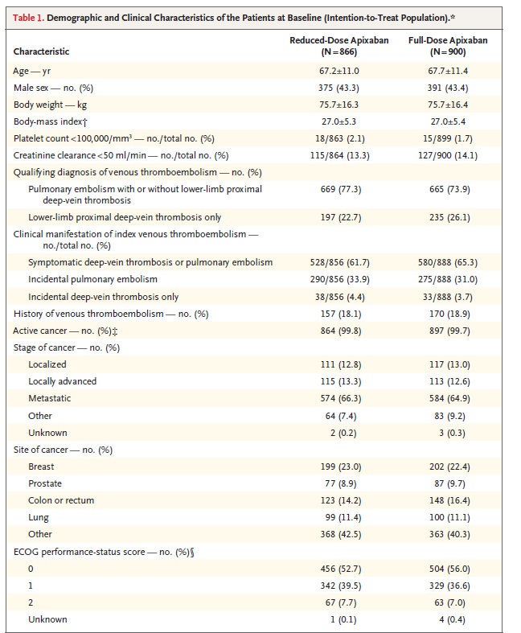

Reproduced from Mahé I, et al. *NEJM.* 2025;392:1363–73, Table 1.

### 關鍵基線數字

- 平均年齡 ~67 歲；43% 男性
- **Active cancer ≥99.7%**
- Metastatic 65%；locally advanced 13%
- Index event 含 PE: 75%
- 癌症位置：乳癌 23% · 肺 11% · 結直腸 15%
- ECOG 0/1: ~92%

兩組基線高度均衡 — 隨機分層依 trial centre、index event 種類、cancer site

API-CAT · Primary Outcome

# 主要結果：Apixaban 2.5 mg BID 非劣於 5 mg BID

12 個月累積復發率 2.1% vs 2.8%；Adjusted subhazard ratio 0.76 (0.41–1.41); P<sub>NI</sub> = 0.001

Cumulative incidence of recurrent VTE (ITT)

[figure not shown]

Full-dose 5 mg BID Reduced-dose 2.5 mg BID

**結論一：**2.5 mg BID 在 active cancer 病人延長治療  
不會顯著增加 VTE 復發。

- 事件數絕對差: 2.1% vs 2.8% (–0.7 pp)
- HR 95% CI 上限 1.41 < 預設 2.0 NI margin
- Net clinical benefit: HR 0.96 (0.87–1.07)

Reproduced & redrawn from Mahé I, et al. *NEJM.* 2025;392:1363–73, Figure 2.

API-CAT · Key Secondary Outcome

# 減劑量同時降低臨床顯著出血

12 個月累積出血率 12.1% vs 15.6%；Adjusted SHR 0.75 (0.58–0.97); P = 0.03

Cumulative incidence of clinically relevant bleeding (ITT)

[figure not shown]

Full-dose 5 mg BID Reduced-dose 2.5 mg BID

**結論二：**2.5 mg BID 在延長期治療中  
**顯著降低 25% 臨床顯著出血**（NNH ~28）

| Bleeding 子項 | SHR (95% CI) |
| --- | --- |
| Major bleeding | 0.66 (0.40–1.10) |
| Major GI bleeding | NR |
| CRNM bleeding | 0.79 (0.59–1.05) |

Reproduced & redrawn from Mahé I, et al. *NEJM.* 2025;392:1363–73, Figure 2.

API-CAT · Take-Home

# API-CAT 結論 — 改變實務的臨床問題

1. 對 active cancer 且已完成 ≥6 個月抗凝的病人，**apixaban 2.5 mg BID 在延長治療階段非劣於 5 mg BID**，仍能持續預防 VTE 復發。
2. 同時 **2.5 mg BID 降低 25% 臨床顯著出血**（adjusted SHR 0.75; 95% CI 0.58–0.97; P = 0.03）。
3. 全因死亡兩組相似 (HR 0.96, 0.86–1.06)；net clinical benefit 兩組相當。
4. API-CAT 直接回答「6 個月後該怎麼辦」這個臨床日常困擾 — 對 Priya 這類病人，**降劑量延長治療成為首選**。

**SmPC 提醒：**當 prevention of recurrent DVT/PE 為適應症時，**2.5 mg BID 應於 ≥6 個月 5 mg BID 治療後啟動**。

Mahé I, et al. *N Engl J Med.* 2025;392:1363–73 · Eliquis® SmPC. Apr 2025.

PART · D

# 延長治療 (Extended) — 無癌症病人

Unprovoked VTE · Recurrence

# Unprovoked VTE — 復發風險明顯較高

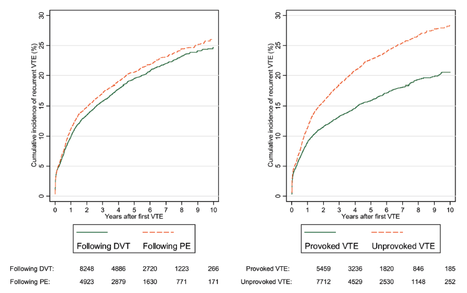

Reproduced from Martinez C, et al. *Thromb Haemost.* 2014;112:255–63.

*28.4%*Unprovoked VTE 10 年復發率

20.5%Provoked VTE 10 年復發率

- **Unprovoked VTE**：無近期主要 VTE 風險因子、未使用荷爾蒙治療
- **Provoked VTE**：近 3 個月內有暫時性主要風險因子（手術、外傷、孕產期、長期臥床）或使用荷爾蒙治療

Minor persistent / transient risk factors（IBD、肥胖、血栓傾向、長途旅行）的復發率與 unprovoked 相似 — 也應考慮延長治療。

Long-term risk after first unprovoked VTE

# 風險不會「過了一年就消失」 — 10 年下來累積 36%

18 篇 study, 7,515 位 first unprovoked VTE 病人 (Kahn 2019)

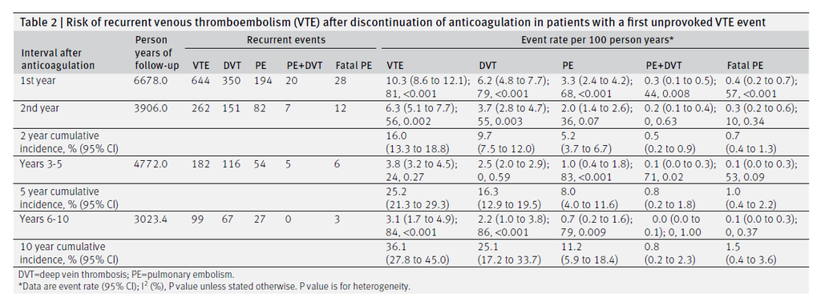

Reproduced from Kahn F, et al. *BMJ.* 2019;366:l4363, Table 2.

| 時間 | VTE 事件率 每 100 病人年 | 累積復發 |
| --- | --- | --- |
| 1 年 | 10.3 (8.6–12.1) | 10.3% |
| 2 年 | 6.3 (5.1–7.7) | 16.0% |
| 3–5 年 | 3.8 (3.2–4.5) | 25.2% |
| 10 年 | 3.1 (1.7–4.9) | **36.1%** |

**意涵：**3 個月或 6 個月療程結束後若停藥，10 年內 ~1/3 病人會再發 — 這是 AMPLIFY-EXT 與 EINSTEIN-CHOICE 出現的原因。

AMPLIFY-EXT · NEJM 2013

# AMPLIFY-EXT：Apixaban 2.5 mg BID vs 安慰劑

2,486 位完成 6–12 個月標準抗凝的病人；>90% unprovoked；治療 12 個月

[output not shown]

*14*NNT 預防 1 起  
復發 VTE / VTE-related death

200NNH 造成 1 起  
major + CRNM bleed

Agnelli G, et al. *N Engl J Med.* 2013;368:699–708. Apixaban 2.5 mg BID 為 VTE 二級預防的**仿單劑量**。

RENOVE · Lancet 2025